# R Notebook

```r
library(caret)
```

All models are wrong, but some are useful – George Box

Models should be as simple as possible, but no simpler

Another word for making a model simple is *bias* The opposite – inserting too many variable – is called *variance*

This leads us to the `bias - variance trade-off`

> Fit the data, not the noise

The more we “fit the data” the more bias we have The more we “fit the noise” the more variance we have

```r
savings
```

| gender | name | surname | job_area | salary | age | retired | location | savings |
| --- | --- | --- | --- | --- | --- | --- | --- | --- |
| Female | Helena | Mowat | Human Resources | 28000 | 48 | No | Western Isles | 31700 |
| Female | Dora | Williamson | Training | 20000 | 55 | No | Edinburgh | 48553 |
| Male | Harry | Halcrow | Product Management | 17000 | 42 | No | Western Isles | 33809 |
| Male | Freddy | Peterson | Legal | 17000 | 66 | Yes | Inverness | 24617 |
| Female | Gilly | Henderson | Product Management | 16000 | 55 | No | Aberdeen | 29254 |
| Female | India | Thomason | Sales | 29000 | 49 | No | Glasgow | 42866 |
| Male | Ivan | Mowat | Training | 16000 | 79 | Yes | Shetland | 22095 |
| Male | Harry | Mowat | Legal | 22000 | 60 | No | Aberdeen | 34651 |
| Female | Cara | Smith | Legal | 21000 | 53 | No | Orkney | 38149 |
| Female | Bonnie | Fraser | Human Resources | 25000 | 69 | Yes | Orkney | 18038 |

[output cut: 990 more lines]

```r
lm_overfit <- lm(savings ~ ., data = savings)
lm_wellfit <- lm(savings ~ salary + age + retired, data = savings)
lm_underfit <- lm(savings ~ salary, data = savings)
```

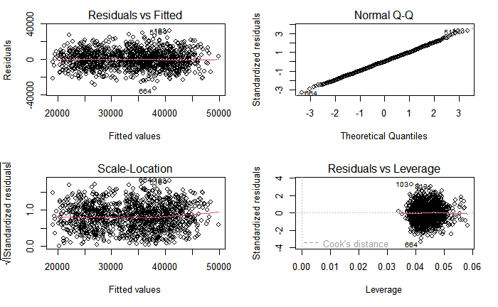

```r
par(mfrow = c(2,2))

plot(lm_overfit)
```

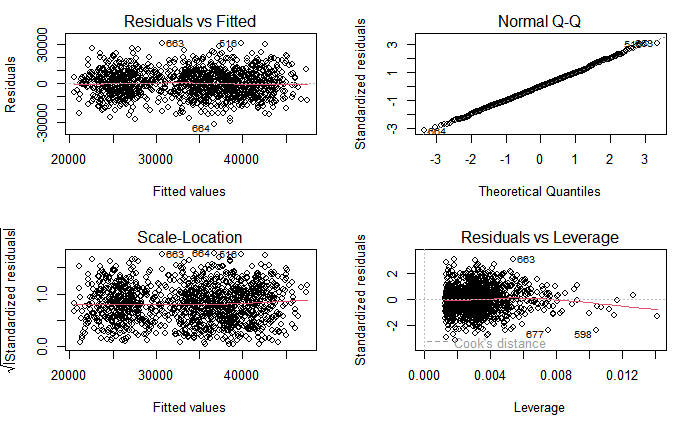

```r
plot(lm_wellfit)
```

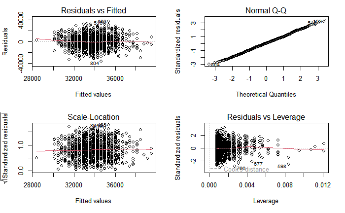

```r
plot(lm_underfit)
```

Find the R-squared, adjusted R-squared, AIC and BIC score for: The well-fitted model model_wellfit <- lm(savings ~ salary + age + retired, data = savings) The over-fitted model model_overfit <- lm(savings ~ ., data = savings) The under-fitted model model_underfit <- lm(savings ~ salary, data = savings) Do the results you found match with your expectations?

```r
summary(lm_wellfit)$r.squared
```

```
[1] 0.3090059
```

```r
AIC(lm_wellfit)
```

```
[1] 25496.62
```

```r
BIC(lm_wellfit)
```

```
[1] 25522.07
```

```r
summary(lm_overfit)$r.squared
```

```
[1] 0.3345468
```

```r
AIC(lm_overfit)
```

```
[1] 25549.42
```

```r
BIC(lm_overfit)
```

```
[1] 25824.29
```

```r
summary(lm_underfit)$r.squared
```

```
[1] 0.01672324
```

```r
AIC(lm_underfit)
```

```
[1] 25915.93
```

```r
BIC(lm_underfit)
```

```
[1] 25931.2
```

R2

```r
summary(lm_wellfit)$r.squared
```

```
[1] 0.3090059
```

```r
summary(lm_overfit)$r.squared
```

```
[1] 0.3345468
```

```r
summary(lm_underfit)$r.squared
```

```
[1] 0.01672324
```

Adjusted R2

```r
summary(lm_wellfit)$adj.r.squared
```

```
[1] 0.3072727
```

```r
summary(lm_overfit)$adj.r.squared
```

```
[1] 0.304378
```

```r
summary(lm_underfit)$adj.r.squared
```

```
[1] 0.01590247
```

AIC

```r
AIC(lm_wellfit)
```

```
[1] 25496.62
```

```r
AIC(lm_overfit)
```

```
[1] 25549.42
```

```r
AIC(lm_underfit)
```

```
[1] 25915.93
```

BIC

```r
BIC(lm_wellfit)
BIC(lm_overfit)
BIC(lm_underfit)
```

[output not shown]

## Test and train sets

One dataset

Let’s say we have 1,000,000 rows.

Split the data into two separate datasets.

Training set Test set

What are each of these for? How much data should we apportion to each?

- We want to use as much as possible for the training.
  - 70 / 30
  - 80 / 20
- Use the rest for testing (or validation)
- If the model performs well on the test set:
  - we expect it to also perform well on the training set
  - if it performs poorly, model is likely over- or under-fit

How do we combat overfitting? - Theory. - Sometimes this is easy: salary probably affects savings - Sometimes less clear: location affects savings???

```r
set.seed(9)     # dont do this in real life

n_data <- nrow(savings)

test_index <- sample(1:n_data, size = n_data * .2)

test <- slice(savings, test_index)
train <- slice(savings, -test_index)
```

```r
#train the model
lm1 <- lm(savings ~ salary + age + retired, data = train) # model using the training set only

#create predictions for the test set
pred_test <- test %>%
    add_predictions(lm1) %>%
    select(savings, pred)
```

```r
mse_test <- mean((pred_test$pred - test$savings)^2)
```

[output not shown]

```r
pred_train <- train %>%
    add_predictions(lm1) %>%
    select(savings, pred)

mse_train <- mean((pred_test$pred - test$savings)^2)
```

## K-fold cross validation

K = 5 5 partitions K = 10 10 partitions

uses `caret` library

```r
model
```

```
Linear Regression

1200 samples
   3 predictor

No pre-processing
Resampling: Cross-Validated (10 fold)
Summary of sample sizes: 1080, 1080, 1080, 1080, 1080, 1080, ...
Resampling results:

  RMSE      Rsquared   MAE
  9896.834  0.3152612  7902.707

Tuning parameter 'intercept' was held constant at a value of TRUE
```

```r
model$resample
```

| RMSE | Rsquared | MAE | Resample |
| --- | --- | --- | --- |
| 10669.741 | 0.3406485 | 8603.247 | Fold01 |
| 10333.100 | 0.2271195 | 8139.450 | Fold02 |
| 8340.169 | 0.4552094 | 6742.725 | Fold03 |
| 9364.178 | 0.3818896 | 7471.393 | Fold04 |
| 9636.160 | 0.2811805 | 7794.606 | Fold05 |
| 11008.679 | 0.1987878 | 8876.362 | Fold06 |
| 11062.921 | 0.2320150 | 8750.427 | Fold07 |
| 9105.973 | 0.4651649 | 7026.382 | Fold08 |
| 9360.507 | 0.2833562 | 7498.990 | Fold09 |
| 10086.908 | 0.2872408 | 8123.492 | Fold10 |

```r
mean(model$resample$RMSE)
```

```
[1] 9896.834
```

```r
mean(model$resample$Rsquared)
```

```
[1] 0.3152612
```

```r
model_allvariables <- train(savings ~ .,
               data = savings,
               trControl = cv_10_fold,
               method = "lm")
```

```r
model_allvariables$resample
```

| RMSE | Rsquared | MAE | Resample |
| --- | --- | --- | --- |
| 10900.905 | 0.2608828 | 8770.229 | Fold01 |
| 10259.360 | 0.2198168 | 8169.139 | Fold02 |
| 9819.274 | 0.2836313 | 7842.380 | Fold03 |
| 10156.619 | 0.2911184 | 8245.488 | Fold04 |
| 10938.870 | 0.2684747 | 8313.031 | Fold05 |
| 9444.182 | 0.3832304 | 7700.461 | Fold06 |
| 10237.969 | 0.2111984 | 8056.031 | Fold07 |
| 10765.978 | 0.2671143 | 8631.578 | Fold08 |
| 9235.157 | 0.3029963 | 7498.879 | Fold09 |
| 10060.247 | 0.2635353 | 8031.966 | Fold10 |

```r
mean(model_allvariables$resample$RMSE)
```

```
[1] 10181.86
```

```r
mean(model_allvariables$resample$Rsquared)
```

[output not shown]

## Automated model development

### Backward selection

Start with the model containing all possible predictors (the so-called **‘full’ model**)

- At each step, check all predictors in the model, and find the one that lowers r2 the *least* when it is removed.
- Remove this predictor from the model
- Keep note of the number of predictors in the model and the current model formula
- Go on to remove another predictor, or stop if all predictors in the model have been remove

### Best-subsets

particularly seductive

Checks every possible variation of predictors Scales REALLY BADLY. Can take coicidences as real!

```r
summary(regsubsets_forward)
```

```
Subset selection object
Call: regsubsets.formula(charges ~ ., data = insurance, nvmax = 8,
    method = "forward")
8 Variables  (and intercept)
                Forced in Forced out
age                 FALSE      FALSE
sexmale             FALSE      FALSE
bmi                 FALSE      FALSE
children            FALSE      FALSE
smokeryes           FALSE      FALSE
regionnorthwest     FALSE      FALSE
regionsoutheast     FALSE      FALSE
regionsouthwest     FALSE      FALSE
1 subsets of each size up to 8
Selection Algorithm: forward
         age sexmale bmi children smokeryes regionnorthwest regionsoutheast regionsouthwest
1  ( 1 ) " " " "     " " " "      "*"       " "             " "             " "
2  ( 1 ) "*" " "     " " " "      "*"       " "             " "             " "
3  ( 1 ) "*" " "     "*" " "      "*"       " "             " "             " "
4  ( 1 ) "*" " "     "*" "*"      "*"       " "             " "             " "
5  ( 1 ) "*" " "     "*" "*"      "*"       " "             "*"             " "
6  ( 1 ) "*" " "     "*" "*"      "*"       " "             "*"             "*"
7  ( 1 ) "*" " "     "*" "*"      "*"       "*"             "*"             "*"
8  ( 1 ) "*" "*"     "*" "*"      "*"       "*"             "*"             "*"
```

[figure not shown]

[figure not shown]

```r
regsubsets_backward <- regsubsets(charges ~ ., data = insurance, nvmax = 8, method = "backward")
regsubsets_exhaustive <- regsubsets(charges ~ ., data = insurance, nvmax = 8, method = "exhaustive")

mod_without_region <- lm(charges ~ age + bmi + smoker, insurance)
mod_with_region <- lm(charges ~ age + bmi + smoker + region, insurance)

summary(mod_with_region)
```

```
Call:
lm(formula = charges ~ age + bmi + smoker + region, data = insurance)

Residuals:
   Min     1Q Median     3Q    Max
-11905  -3041  -1000   1542  29419

Coefficients:
                 Estimate Std. Error t value Pr(>|t|)
(Intercept)     -11601.56     976.20 -11.884   <2e-16 ***
age                258.64      11.93  21.680   <2e-16 ***
bmi                340.01      28.67  11.858   <2e-16 ***
smokeryes        23852.48     413.51  57.683   <2e-16 ***
regionnorthwest   -303.52     477.85  -0.635   0.5254
regionsoutheast  -1038.63     480.49  -2.162   0.0308 *
regionsouthwest   -915.94     479.56  -1.910   0.0564 .
---
Signif. codes:  0 ‘***’ 0.001 ‘**’ 0.01 ‘*’ 0.05 ‘.’ 0.1 ‘ ’ 1

Residual standard error: 6085 on 1331 degrees of freedom
Multiple R-squared:  0.7487,    Adjusted R-squared:  0.7475
F-statistic: 660.8 on 6 and 1331 DF,  p-value: < 2.2e-16
```

```r
summary(mod_without_region)
```

```
Call:
lm(formula = charges ~ age + bmi + smoker, data = insurance)

Residuals:
     Min       1Q   Median       3Q      Max
-12415.4  -2970.9   -980.5   1480.0  28971.8

Coefficients:
             Estimate Std. Error t value Pr(>|t|)
(Intercept) -11676.83     937.57  -12.45   <2e-16 ***
age            259.55      11.93   21.75   <2e-16 ***
bmi            322.62      27.49   11.74   <2e-16 ***
smokeryes    23823.68     412.87   57.70   <2e-16 ***
---
Signif. codes:  0 ‘***’ 0.001 ‘**’ 0.01 ‘*’ 0.05 ‘.’ 0.1 ‘ ’ 1

Residual standard error: 6092 on 1334 degrees of freedom
Multiple R-squared:  0.7475,    Adjusted R-squared:  0.7469
F-statistic:  1316 on 3 and 1334 DF,  p-value: < 2.2e-16
```

```r
anova(mod_with_region, mod_without_region)
```

```
Analysis of Variance Table

Model 1: charges ~ age + bmi + smoker + region
Model 2: charges ~ age + bmi + smoker
  Res.Df        RSS Df  Sum of Sq      F  Pr(>F)
1   1331 4.9281e+10
2   1334 4.9513e+10 -3 -232012208 2.0887 0.09989 .
---
Signif. codes:  0 ‘***’ 0.001 ‘**’ 0.01 ‘*’ 0.05 ‘.’ 0.1 ‘ ’ 1
```

[figure not shown]

## Human intervention is needed…

These models have not been tested for statistical significance. More importantly, so far, they have been subject to the ADF method - choices *MUST* reflect theory